# Homework - Week 06

```r
library(rethinking)
library(ggplot2)
library(dplyr)
library(tidyr)
library(purrr)
library(dagitty)
# library(patchwork)
```

Conduct a prior predictive simulation for the Reedfrog model. By this I mean to simulate the prior distribution of tank survival probabilities αj. Start by using this prior:

$$\begin{align}
\bar{\alpha}_j \sim Normal(\bar{\alpha}, \sigma) \\
\bar{\alpha} \sim Normal(0, 1) \\
\sigma \sim Exponential(1)\\
\end{align}$$

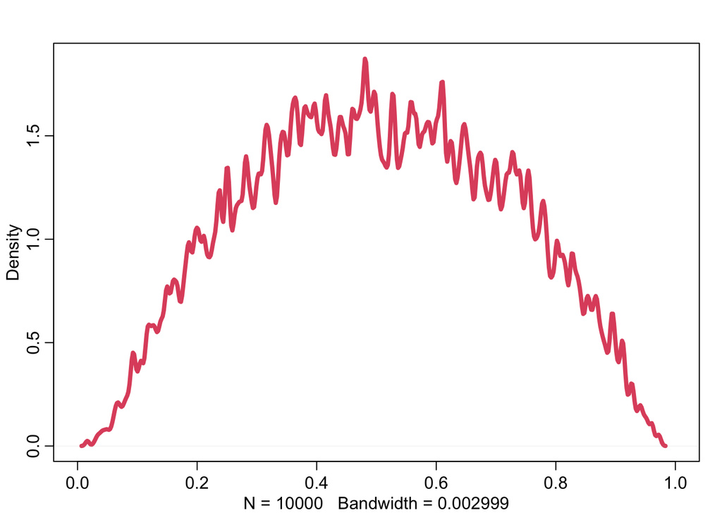

```r
n <- 1e4
sigma <- rexp(n,10)
abar <- rnorm(n,0,1)
aT <- rnorm(n,abar,sigma)
dens(inv_logit(aT),xlim=c(0,1),adj=0.1,lwd=4,col=2)
```

```r
data("reedfrogs")
d <- reedfrogs %>%
  transmute(T= row_number(),
            S = surv,
            G = if_else(size=="big",2,1),
            P = if_else(pred=="pred",1,0),
            D = density,
            Ds = standardize(log(D)))
```

```r
m1.1 <- ulam(
  alist(
    S ~ dbinom(D, p),
    logit(p) <- a[T],
    a[T] ~ dnorm(a_bar, sigma),
    a_bar ~ dnorm(0, 1),
    sigma ~ dexp(1)
  ),
  data = d, chains = 4, cores = 4, log_lik = T
)

precis(m1.1, depth = 2)
```

Train other models with different priors

```r
m1.2 <- ulam(
  alist(
    S ~ dbinom(D, p),
    logit(p) <- a[T],
    a[T] ~ dnorm(a_bar, sigma),
    a_bar ~ dnorm(0, 1),
    sigma ~ dexp(10)
  ),
  data = d, chains = 4, cores = 4, log_lik = T
)
m1.3 <- ulam(
  alist(
    S ~ dbinom(D, p),
    logit(p) <- a[T],
    a[T] ~ dnorm(a_bar, sigma),
    a_bar ~ dnorm(0, 1),
    sigma ~ dexp(0.1)
  ),
  data = d, chains = 4, cores = 4, log_lik = T
)
```

```r
set.seed(9392)
prior_m1.1 <- extract.prior(m1.1)
prior_m1.2 <- extract.prior(m1.2)
prior_m1.3 <- extract.prior(m1.3)
```

```r
models <- list(prior_m1.1, prior_m1.2, prior_m1.3)
sigmas <- c(1, 10, 0.1) %>% as.character()

df_priors_wsigma <- map2_df(
  models, sigmas,
  .f=function(model,sigma){
    p_samples <- inv_logit(model$a)
    mean_p <- p_samples %>% apply(MARGIN=2, FUN=mean)
    p89interval <- p_samples %>% apply(MARGIN=2, FUN=PI) %>% t
    tibble(
      sigma = sigma,
      p = mean_p,
      p5 = p89interval[,1],
      p94 = p89interval[,2]
    ) %>%
      mutate(T = row_number())
  })
```

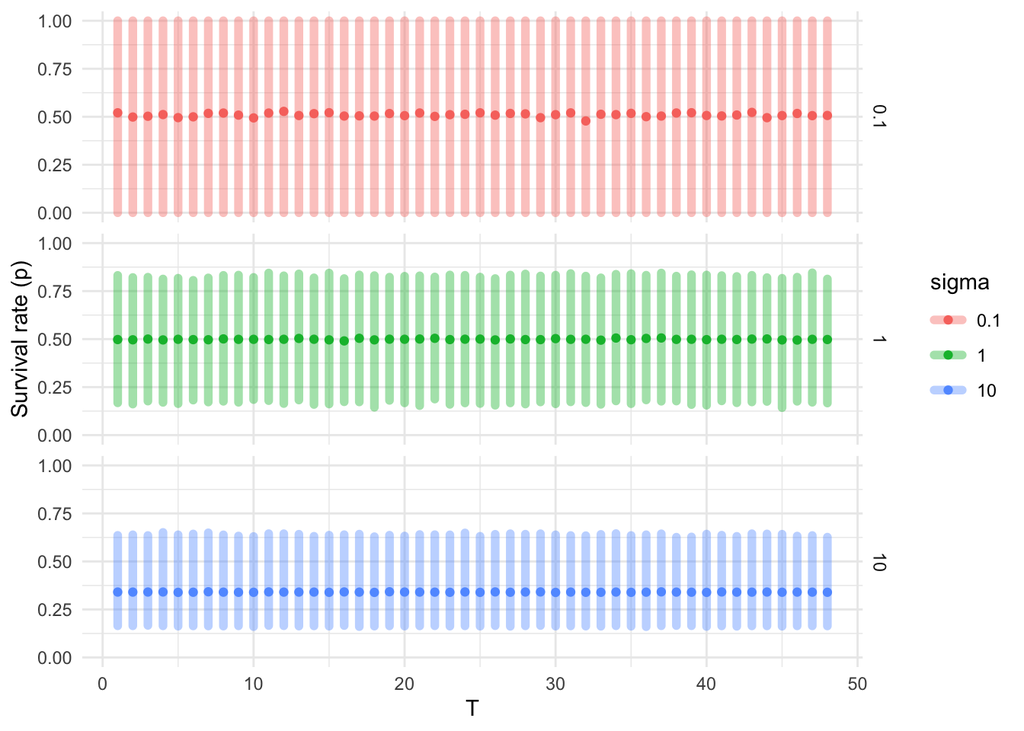

```r
ggplot(df_priors_wsigma) +
  geom_segment(
    aes(x=T, xend=T, y=p5, yend=p94, color=sigma, group=paste(T, sigma)),
    alpha = 0.4, linewidth=2, lineend = "round"
  ) +
  geom_point(aes(x=T, y = p, color=sigma)) +
  labs(y="Survival rate (p)") +
  facet_grid(sigma ~ .) +
  theme_minimal()
```

Be sure to transform the αj values to the probability scale for plotting and summary. How does increasing the width of the prior on σ change the prior distribution of αj? You might try Exponential(10) and Exponential(0.1) for example.

## Problem 02

2. Revisit the Reedfrog survival data, data(reedfrogs). Start with the varying effects model from the book and lecture. Then modify it to estimate the causal effects of the treatment variables `pred` and `size`, including how size might modify the effect of predation. An easy approach is to estimate an effect for each combination of `pred` and `size`. Justify your model with a DAG of this experiment.

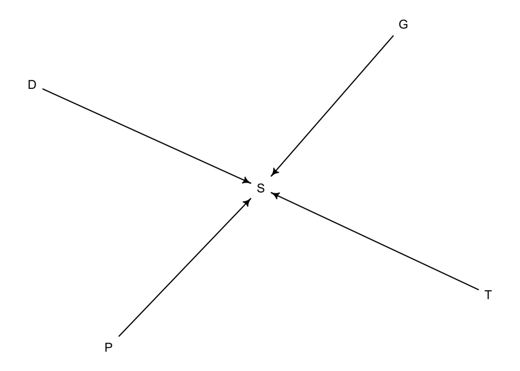

```r
dag_reedfrogs <- dagitty(
  "dag {
  T -> S
  D -> S
  G -> S
  P -> S
  }"
)

drawdag(dag_reedfrogs)
```

```r
m2.1 <- ulam(
  alist(
    S ~ dbinom( D , p ) ,
    logit(p) <- a[T] + bP[G]*P ,
    bP[G] ~ dnorm( 0 , 0.5 ),
    a[T] ~ dnorm( a_bar , sigma ) ,
    a_bar ~ dnorm( 0 , 1.5 ) ,
    sigma ~ dexp( 1 )
  ), data=d , chains=4, cores=4,  log_lik=TRUE )
```

```r
precis(m2.1, pars=c("bP", "sigma"), depth = 2)
```

```
            mean        sd       5.5%     94.5%    n_eff    Rhat4
bP[1] -0.9869021 0.3384580 -1.5342488 -0.430972 292.4637 1.006782
bP[2] -1.6512721 0.3642176 -2.2351831 -1.041882 229.6938 1.000585
sigma  1.0035948 0.2013285  0.7208531  1.361816 270.4872 1.001044
```

- `extract.samples`: Extracts or draw samples from fit models.
- `link`: Computes inverse-link linear model values for map and map2stan samples.
- `sim`: Simulates posterior observations for map and map2stan model fits.

```r
pred <- d$P %>% unique() %>% sort # 0,1
size <- d$G %>% unique() %>% sort # 1,2

grid <- expand_grid(pred, size) %>%
  mutate(label = paste0("P",pred, "_", "G",size))
p_posterior <- map2(
  .x=grid$pred, .y=grid$size,
  .f=function(x,y){
    d_tmp <- d %>%
      split(.$T) %>%
      map2_df(
      ., names(.),
      .f=function(row, tank) tibble(
        T=as.integer(tank), D=1, P=rep(x, row$D), G=rep(y, row$D))
      )
    link(m2.1, data = as.list(d_tmp))
  })
names(p_posterior) <- grid$label
str(p_posterior)
```

```
List of 4
 $ P0_G1: num [1:2000, 1:1120] 0.9 0.92 0.649 0.928 0.958 ...
 $ P0_G2: num [1:2000, 1:1120] 0.9 0.92 0.649 0.928 0.958 ...
 $ P1_G1: num [1:2000, 1:1120] 0.719 0.779 0.513 0.876 0.902 ...
 $ P1_G2: num [1:2000, 1:1120] 0.562 0.66 0.3 0.716 0.877 ...
```

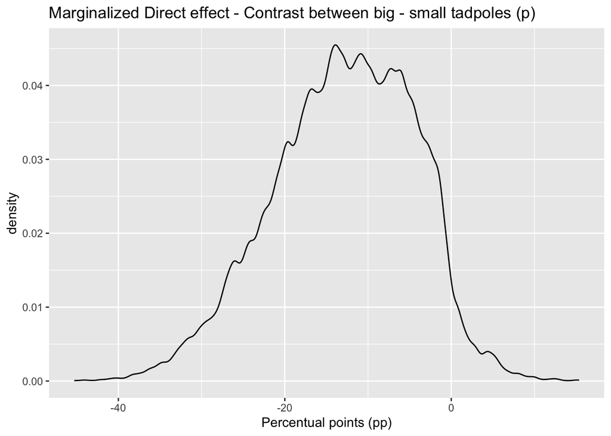

```r
# How size might modify the effect of predator

marginalized_contrast <- p_posterior[["P1_G2"]] - p_posterior[["P1_G1"]]

plot_marginalized_contrast <- ggplot() +
  geom_density(aes(x=as.vector(marginalized_contrast) * 100)) +
  labs(x = "Percentual points (pp)",
       title = "Marginalized Direct effect - Contrast between big - small tadpoles (p)")

plot_marginalized_contrast
```

```r
d %>% group_by(G) %>% summarise(S_rate = sum(S)/sum(D))
```

```
# A tibble: 2 × 2
      G S_rate
  <dbl>  <dbl>
1     1  0.752
2     2  0.646
```

## Problem 03

3. Now estimate the causal effect of density on survival. Consider whether `pred` modifies the effect of density. There are several good ways to include density in your Binomial GLM. You could treat it as a continuous regression variable (possibly standardized). Or you could convert it to an ordered category (with three levels). Compare the σ (tank standard deviation) posterior distribution to σ from your model in Problem 2. How are they different? Why?

```r
precis(m3.1, pars=c("bP", "bDs", "sigma"), depth = 2)
```

[output not shown]

```
             mean        sd       5.5%      94.5%     n_eff    Rhat4
bP[1]  -1.0834716 0.3170522 -1.5744833 -0.5478559  295.9326 1.011393
bP[2]  -1.8183207 0.3422504 -2.3333852 -1.2617411  367.0764 1.005168
bDs[1]  0.1961427 0.2296105 -0.1813394  0.5538714 1120.9622 1.001428
bDs[2] -0.5503002 0.1972871 -0.8591979 -0.2420855  978.4221 1.003270
sigma   0.8107316 0.1826508  0.5561257  1.1269792  346.4161 1.007636
```

```r
compare(m2.1, m3.1)
```

```
         WAIC       SE   dWAIC      dSE    pWAIC    weight
m2.1 199.0077 7.391721 0.00000       NA 19.55853 0.7920069
m3.1 201.6818 7.771653 2.67413 3.247878 19.88931 0.2079931
```

```r
samples_m2.1 <- extract.samples(m2.1)
samples_m3.1 <- extract.samples(m3.1)
```

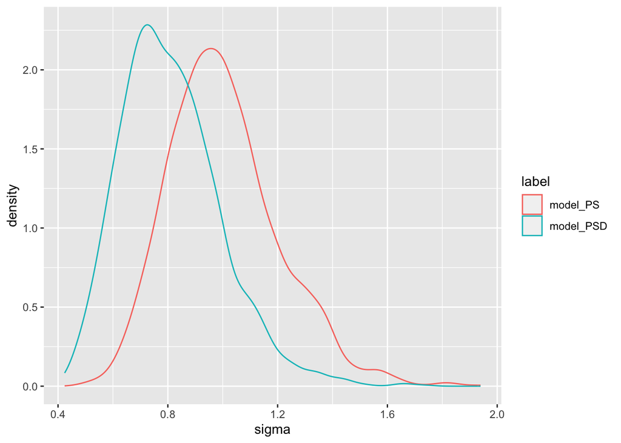

```r
to_plot <- bind_rows(
  tibble(label="model_PS", sigma = samples_m2.1$sigma),
  tibble(label="model_PSD", sigma = samples_m3.1$sigma)
)

ggplot(data=to_plot) +
  geom_density(aes(x=sigma, color=label))
```

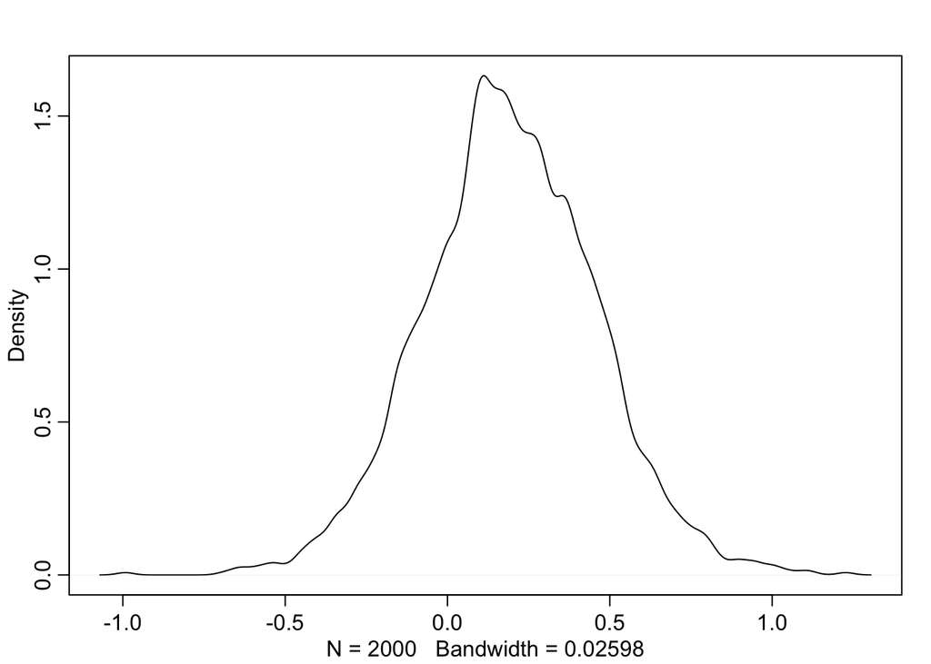

```r
dens(samples_m2.1$sigma - samples_m3.1$sigma)
```